# Francesco Fico Project

Francesco Fico

# 1 Question 1

To investigate the structure of the sequencing data, we examined the FASTQ files to reconstruct the composition of the reads. The dataset contains two adapter sequences and four primer pairs (forward and reverse). The absence of adapter matches suggests that adapter trimming had already been performed before the data were provided.

```r
# Quick inspection of the FASTQ files
aln1 <- readFastq("C:/Users/ficof/Desktop/malta/sequenceFile/sequenceFile/aln1.fastq/aln1.fastq")
aln2 <- readFastq("C:/Users/ficof/Desktop/malta/sequenceFile/sequenceFile/aln2.fastq/aln2.fastq")

# Quality control
quality(aln1)
```

```
## class: FastqQuality
## quality:
## BStringSet object of length 575002:
##          width seq
##      [1]   151 ABABBFFFFFFFGGGGGGGGGGHHHHGHHHF...GFHHGHHHGGHHGDHFHHGHHHHHHHGHFHH
##      [2]   151 AA?AABFFF1A?1AFFG1FGGFGCF0EFH0F...CA1D1<?0??GH?CF@FHHFHFBBGGGHHGH
##      [3]   151 A3>AABAFFFFBFEGFAGFGGGHHHHHBGHB...HGFFHHHHHHHGHHHHGHHDGHCEGGG?EHF
##      [4]   151 >1AA111CDBF11A1B13BFE1B131BAEFG.../?0F0EF1112G<0/>1B1BB212>21BF11
##      [5]   151 BBBBCFFFFFFFGGGGGGGGGGHHHHHHHHH...GHHHHHGHHHHHGGHHHHGHDFFHHHGHGGH
##      ...   ... ...
## [574998]   151 A>AA?CFFBAAA1ADCABBAFBGFHGCH1FF...FHFDF21@G<F<?/<@/?DGFGHG00F<DGG
## [574999]   151 BBAABDBFFFFFGFGGC5FGGFFGFHHBGHG.../FCGHHHHHHHGGEF?GGHHHHGFFHHHHHG
## [575000]   151 AAAAA11BDDBDEG1BFFFFFGH1FBE1B3A...EFF2BFGF2BGBBFDBEHHHFGECC/CGCF1
## [575001]   151 A>>>>3B3BDFFGGGGB1AGG1EGCHHHHGG...?/CGCHHAGHFGHFHGHHHFHDFGHHBGHG/
## [575002]   151 BBBBBFFFFBBBGGGGGAFCFGGGGHGHHHH...EFHHHHHHHHHHGGGCGGHHFFECCDGHHH=
```

```r
quality(aln2)
```

```
## class: FastqQuality
## quality:
## BStringSet object of length 575002:
##          width seq
##      [1]   151 #>>AAAFBA1BAEGGFAFGGFGHGHCG0GHB...@CBC?<@FHH2BDGFHFGGGHGGGFF?FG0?
##      [2]   151 #1>>1>B@@DF11B1A1AEEGGB11AAFF0E...1BFB///?F1<@@/?F<C</????A..1>C.
##      [3]   151 #1>1>1FF?1ADEGGGCGGF0F1FGDFG0FG...00FF9BFFFGBC;F9/.;0B0=9/;/:/BFB
##      [4]   151 #>>AA1CCAFF@EGGGGGGEBF1BDEHCF0E.../<>C/<B@FG>112FFHG>2@01F1D???/?
##      [5]   151 A??AAFFFBFFBGGGGGCGFGGHHHGHHHHG...EBCG/>@GDGHHHHHGGHHHHHFHHH?1F??
##      ...   ... ...
## [574998]   151 >1>>AA1DFFB1AAEGGAGGGFFHHGFFGEE...BB0?0/?GFBFFHB1@@?>FHCFGF?F1?G/
## [574999]   151 >>A1111BA@B>1FFEF0FFBEHHHFHCHHH...EBCC?>GGGHHFDHFHFBHHHGHGFGBDF0?
## [575000]   151 >AA>>CCB>BBAEA1AA00AB0AGFDACHHF...HHHGBG0@<1@D10@F/01?1?<?1<?1<?1
## [575001]   151 AAAA1CA>@CAAAFG11BBEBFF0AF1B0FB...C:-..;/;=9B0B:/.9.FE9.;@-;@@9--
## [575002]   151 ABAB3BFFFFFFGFFFFGGGEFGGHHHHFEG...GHCCDG?F@@11@GHGF?</FE/>@--<<G.
```

```r
table(width(sread(aln1)))
```

```
##
##    151
## 575002
```

```r
table(width(sread(aln2)))
```

```
##
##    151
## 575002
```

```r
# Check whether the adapter sequences are present in the reads
adapter1 <- DNAString("AAGACTCGGCAGCATCTCCA")
adapter2 <- DNAString("GCGATCGTCACTGTTCTCCA")

primerF1 <- DNAString("TTGCCAGTTAACGTCTTCCTTCTCTCTCTG")
primerF2 <- DNAString("CCCTTGTCTCTGTGTTCTTGTCCCCCCCA")
primerF3 <- DNAString("TGATCTGTCCCTCACAGCAGGGTCTTCTCT")
primerF4 <- DNAString("CACACTGACGTGCCTCTCCCTCCCTCCA")

primerR1 <- DNAString("GAGAAAAGGTGGGCCTGAGGTTCAGAGCCA")
primerR2 <- DNAString("CCCCACCAGACCATGAGAGGCCCTGCGGCC")
primerR3 <- DNAString("TGACCTAAAGCCACCTCCTTA")
primerR4 <- DNAString("CCGTATCTCCCTTCCCTGATTA")

# If the reads had not been trimmed, the number of adapter matches would be similar
# to the total number of reads.
sum(vcountPattern(adapter1, sread(aln1)))
```

```
## [1] 4013
```

```r
sum(vcountPattern(adapter2, sread(aln1)))
```

```
## [1] 7
```

```r
sum(vcountPattern(adapter1, sread(aln2)))
```

```
## [1] 0
```

```r
sum(vcountPattern(adapter2, sread(aln2)))
```

```
## [1] 2
```

In this case, only a very small number of matches is detected, likely due to short similar sequences inside the amplicons. Therefore, the adapters have already been removed from the dataset.

```r
# Total number of reads: 575,002
# Count reads containing forward primers in aln1
sum(vcountPattern(primerF1, sread(aln1))) # 203160
```

```
## [1] 203160
```

```r
sum(vcountPattern(primerF2, sread(aln1))) # 6432
```

```
## [1] 6432
```

```r
sum(vcountPattern(primerF3, sread(aln1))) # 97037
```

```
## [1] 97037
```

```r
sum(vcountPattern(primerF4, sread(aln1))) # 144222
```

```
## [1] 144222
```

```r
# Total: 450851 -> 78.4%

# Count reads containing reverse primers in aln2
sum(vcountPattern(primerR1, sread(aln2))) # 182673
```

```
## [1] 182673
```

```r
sum(vcountPattern(primerR2, sread(aln2))) # 8056
```

```
## [1] 8056
```

```r
sum(vcountPattern(primerR3, sread(aln2))) # 90461
```

```
## [1] 90461
```

```r
sum(vcountPattern(primerR4, sread(aln2))) # 128542
```

```
## [1] 128542
```

```r
# Total: 409732 -> 71.2%
```

```r
# Read length
summary(width(sread(aln1))) # 151 bp
```

```
##    Min. 1st Qu.  Median    Mean 3rd Qu.    Max.
##     151     151     151     151     151     151
```

```r
summary(width(sread(aln2))) # 151 bp
```

```
##    Min. 1st Qu.  Median    Mean 3rd Qu.    Max.
##     151     151     151     151     151     151
```

```r
# For curiosity, look at the 30 most frequent 30-bp starting sequences
starts <- substr(as.character(sread(aln1)), 1, 30)
sort(table(starts), decreasing = TRUE)[1:20]
```

```
## starts
## TTGCCAGTTAACGTCTTCCTTCTCTCTCTG CACACTGACGTGCCTCTCCCTCCCTCCAGG
##                         203060                         143674
## TGATCTGTCCCTCACAGCAGGGTCTTCTCT CACACTGACGTGCCTCTCCTAGACTATGCT
##                          97002                          12326
## CCCTTGTCTCTGTGTTCTTGTCCCCCCCAG CACACTGACGTGCCTCTCCCCCTTGTCTCA
##                           6098                           3096
## CACACTGACGTGCCTCTCCTGCCACCCTCT CACACTGACGTGCCTCTCATGGTCTGGTGG
##                           2490                           2388
## CACACTGACGTGCCTCTCCTGGTCTGGTGG CACACTGACGTGCCTCTCCAAGACTCGGCA
##                           2248                           2203
## TTGCCAGTTAACGTCTTCCTTAAGACTCGG TTATCTGTCCCTCACAGCAGGGTCTTCTCT
##                           1563                           1408
## CACACTGACGTGCCTCTCCCTCCAGGAAGC CACACTGACGTGCCTCTCCTTGAAGCTGGG
##                           1154                           1119
## TTGCCAGTTAACGTCTTCCTTCAGGGAAGG TTGCCAGTTAACGTCTTCCTTCGCGCCAAG
##                            837                            819
## TTGCCAGTTAACGTCTTCCTTCTCTCTGTC TTGCCAGTTAACGTCTTCCTTGTCTCATGG
##                            815                            754
## TTGCCAGTTAACGTCTTCCTTACCCTTGTC CACTGACGTGCCTCTCCCTCCCTCCAGGAA
##                            752                            750
```

```r
# As expected, most of them correspond to primer-derived sequences.

# If we allow one mismatch
sum(vcountPattern(primerF1, sread(aln1), max.mismatch = 1)) # 216665
```

```
## [1] 216665
```

```r
sum(vcountPattern(primerF2, sread(aln1), max.mismatch = 1)) # 8452
```

```
## [1] 8452
```

```r
sum(vcountPattern(primerF3, sread(aln1), max.mismatch = 1)) # 105619
```

```
## [1] 105619
```

```r
sum(vcountPattern(primerF4, sread(aln1), max.mismatch = 1)) # 153206
```

```
## [1] 153206
```

```r
# Total: 483942 -> 84%

# The number of matching reads increases, as expected.
# This likely reflects sequencing errors, incomplete trimming,
# or small differences from the expected primer sequence.
# For a qualitative analysis, we keep the exact-match result as the main reference.

# For the downstream mapping step, these reads are still aligned
# to the reference genome, so the main effect is a slight reduction in
# the number of exact primer matches.
```

# 2 Question 2

To identify the gene targeted by the sequencing experiment, we first examined the chromosome-level distribution of the mapped reads and then inspected the coverage profile across the dominant chromosome. The vast majority of the reads map to chromosome 7, so we focus the analysis on this chromosome.

```r
bam <- BamFile("C:/Users/ficof/Desktop/malta/sequenceFile/sequenceFile/aln.bam")

# Inspect the BAM index to see which chromosome contains the highest number of mapped reads
idx <- idxstatsBam(bam)

# Calculate the percentage of mapped reads per chromosome
100 * idx$mapped / sum(idx$mapped)
```

```
##  [1] 1.465361e-01 1.037054e-01 9.971671e-02 2.817234e+00 8.024821e-02
##  [6] 9.791231e-02 9.432175e+01 1.068393e-01 4.321057e-02 1.549883e-01
## [11] 9.202428e-02 3.703763e-02 6.837717e-03 1.604964e-02 2.089302e-02
## [16] 2.810112e-01 4.700931e-02 6.457844e-02 8.446480e-01 6.001996e-02
## [21] 4.776905e-02 3.296350e-01 1.772108e-01 1.519493e-03 0.000000e+00
## [26] 0.000000e+00 0.000000e+00 9.496829e-05 0.000000e+00 0.000000e+00
## [31] 1.899366e-04 0.000000e+00 0.000000e+00 0.000000e+00 0.000000e+00
## [36] 0.000000e+00 0.000000e+00 0.000000e+00 0.000000e+00 0.000000e+00
## [41] 0.000000e+00 0.000000e+00 0.000000e+00 0.000000e+00 0.000000e+00
## [46] 0.000000e+00 0.000000e+00 0.000000e+00 0.000000e+00 0.000000e+00
## [51] 0.000000e+00 0.000000e+00 0.000000e+00 0.000000e+00 0.000000e+00
## [56] 0.000000e+00 1.139620e-03 0.000000e+00 0.000000e+00 0.000000e+00
## [61] 0.000000e+00 0.000000e+00 0.000000e+00 1.899366e-04 0.000000e+00
## [66] 0.000000e+00 0.000000e+00 0.000000e+00 0.000000e+00 0.000000e+00
## [71] 0.000000e+00 0.000000e+00 0.000000e+00 0.000000e+00 0.000000e+00
## [76] 0.000000e+00 0.000000e+00 0.000000e+00 0.000000e+00 0.000000e+00
## [81] 0.000000e+00 0.000000e+00 0.000000e+00 0.000000e+00 0.000000e+00
```

```r
# Restrict the analysis to chr7
gal <- readGAlignments(bam)
gr <- granges(gal)

# Select only the chr7 portion
target_gr <- gr[seqnames(gr) == "7"]

covg <- coverage(target_gr)
chr7_cov <- covg[["7"]]

# Regions with coverage >100x are considered true amplicons rather than sporadic alignments
peaks <- slice(chr7_cov, lower = 100)

ranges(peaks)
```

```
## IRanges object with 5 ranges and 0 metadata columns:
##           start       end     width
##       <integer> <integer> <integer>
##   [1]  55241584  55241796       213
##   [2]  55242379  55242574       196
##   [3]  55248957  55249194       238
##   [4]  55259375  55259589       215
##   [5] 129945985 129946111       127
```

```r
# Inspect the mean coverage to identify the genuine target regions
viewMeans(peaks)
```

```
## [1]  12654.1174 355168.9184 200531.6008 150304.7349    178.2598
```

The first four peaks are close to each other and correspond to the target region, while the fifth one is more distant and much weaker. The four main peaks map within the **EGFR** (Epidermal Growth Factor Receptor) gene region on chromosome 7.

# 3 Question 3

The overall mapping rate was high, indicating that the vast majority of sequencing reads could be successfully aligned to the human reference genome.

```r
# To check how many reads are mapped, extract BAM statistics
stats <- idxstatsBam(bam)

# Save the mapped and unmapped reads and calculate the percentage
mapped <- sum(stats$mapped)
unmapped <- sum(stats$unmapped)
mapping_rate <- mapped / (mapped + unmapped) * 100
mapping_rate
```

```
## [1] 91.56342
```

Only a small fraction of the reads do not map to the reference genome. This can be explained by sequencing errors, residual primer sequences, low-quality bases, or non-specific amplification products.

# 4 Question 4

Coverage was evaluated across the five regions identified from the alignment data. For each peak, we calculated the mean, minimum, and maximum coverage values in order to assess the uniformity of sequencing depth across the target regions.

```r
# Build a dataframe with coverage statistics
amplicon_stats <- data.frame(
  Amplicon = paste0("Amp", 1:length(peaks)),
  Start = start(ranges(peaks)),
  End = end(ranges(peaks)),
  Width = width(ranges(peaks)),
  MeanCov = round(viewMeans(peaks)),
  MaxCov = round(viewMaxs(peaks)),
  MinCov = round(viewMins(peaks)))

# Mean, maximum, and minimum coverage for each detected peak
amplicon_stats
```

```
##   Amplicon     Start       End Width MeanCov MaxCov MinCov
## 1     Amp1  55241584  55241796   213   12654  17984   8753
## 2     Amp2  55242379  55242574   196  355169 441365 214335
## 3     Amp3  55248957  55249194   238  200532 317359 152460
## 4     Amp4  55259375  55259589   215  150305 214699 100307
## 5     Amp5 129945985 129946111   127     178    179    154
```

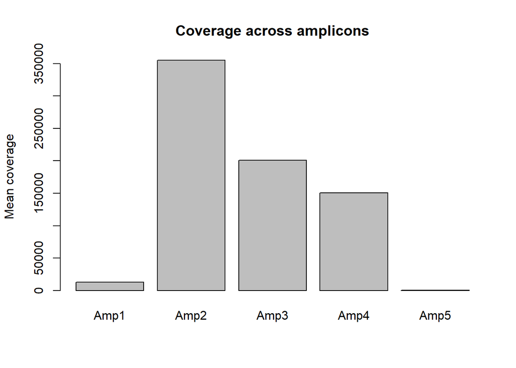

```r
# Plot the mean coverage across the amplicons
barplot(
  amplicon_stats$MeanCov,
  names.arg = amplicon_stats$Amplicon,
  ylab = "Mean coverage",
  main = "Coverage across amplicons")
```

The four peaks corresponding to the EGFR locus show high coverage and are consistent with genuine target amplicons. Peak 5 is much weaker and is interpreted as background noise, off-target amplification, or a spurious alignment rather than a true target region.

# 5 Question 5

Variant identification was performed using the variant caller **iVar** on the Galaxy platform and then manually inspected in **IGV**. Three candidate variants were identified within the **EGFR** locus and supported by the sequencing data. Two of them correspond to single-nucleotide substitutions, while the third one is an in-frame 15-bp deletion.

```r
# Load VCF generated by iVar
vcf <- readVcf("C:/Users/ficof/Desktop/malta/tentativo3.vcf", genome = "hg19")
vcf
```

```
## class: CollapsedVCF
## dim: 80584 0
## rowRanges(vcf):
##   GRanges with 5 metadata columns: paramRangeID, REF, ALT, QUAL, FILTER
## info(vcf):
##   DataFrame with 10 columns: DP, REF_DP, REF_RV, REF_QUAL, ALT_DP, ALT_RV, A...
## info(header(vcf)):
##             Number Type    Description
##    DP       1      Integer Total Depth
##    REF_DP   1      Integer Depth of reference base
##    REF_RV   1      Integer Depth of reference base on reverse reads
##    REF_QUAL 1      Integer Mean quality of reference base
##    ALT_DP   1      Integer Depth of alternate base
##    ALT_RV   1      Integer Deapth of alternate base on reverse reads
##    ALT_QUAL 1      Integer Mean quality of alternate base
##    AF       1      Float   Frequency of alternate base
##    INDEL    0      Flag    Indicates that the variant is an INDEL.
##    DP4      4      Integer Counts for ref-forward bases, ref-reverse, alt-fo...
## geno(vcf):
##   List of length 0:
```

```r
# Total number of calls
length(vcf)
```

```
## [1] 80584
```

```r
# Explore variant distribution
summary(info(vcf)$AF)
```

```
##    Min. 1st Qu.  Median    Mean 3rd Qu.    Max.
##  0.0200  1.0000  1.0000  0.9855  1.0000  1.0000
```

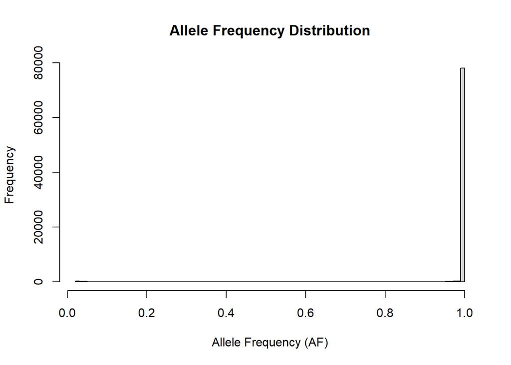

```r
hist(
  info(vcf)$AF,
  breaks = 100,
  main = "Allele Frequency Distribution",
  xlab = "Allele Frequency (AF)")
```

```r
# Remove low-confidence calls
keep <- (info(vcf)$AF > 0.05 & info(vcf)$DP > 100)
vcf_filt <- vcf[keep]
length(vcf_filt)
```

```
## [1] 4308
```

```r
# Restrict the analysis to chromosome 7, which was identified previously as the EGFR chromosome
gr <- rowRanges(vcf_filt)
chr7_idx <- which(as.character(seqnames(gr)) == "7")
vcf_chr7 <- vcf_filt[chr7_idx]
length(vcf_chr7)
```

```
## [1] 866
```

```r
# Quick inspection of chromosome 7 variants
chr7_df <- data.frame(
  pos = start(rowRanges(vcf_chr7)),
  AF = info(vcf_chr7)$AF,
  DP = info(vcf_chr7)$DP,
  ALT_DP = info(vcf_chr7)$ALT_DP)

chr7_df <- chr7_df[order(chr7_df$DP, decreasing = TRUE), ]
head(chr7_df, 20)
```

```
##          pos       AF     DP ALT_DP
## 303 55242465 0.478502 439668 210382
## 289 55242452 0.999050 221027 220817
## 349 55242511 0.998647 221016 220717
## 360 55242522 0.998805 221004 220740
## 348 55242510 0.997792 220972 220484
## 352 55242514 0.998013 220955 220516
## 354 55242516 0.998407 220951 220599
## 362 55242524 0.999212 220935 220761
## 290 55242453 0.995528 220925 219937
## 334 55242496 0.996659 220919 220181
## 288 55242451 0.998959 220900 220670
## 265 55242428 0.999176 220882 220700
## 343 55242505 0.997419 220882 220312
## 365 55242527 0.997926 220872 220414
## 345 55242507 0.997981 220854 220408
## 338 55242500 0.997768 220852 220359
## 293 55242456 0.998682 220850 220559
## 366 55242528 0.996726 220849 220126
## 337 55242499 0.997328 220841 220251
## 356 55242518 0.998986 220836 220612
```

```r
# Define the EGFR amplicons discovered from the coverage analysis
amplicons <- GRanges(
  seqnames = "7",
  ranges = IRanges(
    start = c(55241584, 55242379, 55248957, 55259375),
    end = c(55241796, 55242574, 55249194, 55259589)))

amplicons
```

```
## GRanges object with 4 ranges and 0 metadata columns:
##       seqnames            ranges strand
##          <Rle>         <IRanges>  <Rle>
##   [1]        7 55241584-55241796      *
##   [2]        7 55242379-55242574      *
##   [3]        7 55248957-55249194      *
##   [4]        7 55259375-55259589      *
##   -------
##   seqinfo: 1 sequence from an unspecified genome; no seqlengths
```

```r
# Keep only the variants that fall inside the four EGFR amplicons
hits <- findOverlaps(rowRanges(vcf_chr7), amplicons)
vcf_target <- vcf_chr7[queryHits(hits)]
length(vcf_target)
```

```
## [1] 866
```

```r
# Search for candidate variants with intermediate allele frequencies
cand <- which(info(vcf_target)$AF > 0.20 & info(vcf_target)$AF < 0.80)

cand_df <- data.frame(
  chr = as.character(seqnames(rowRanges(vcf_target)))[cand],
  pos = start(rowRanges(vcf_target))[cand],
  AF = info(vcf_target)$AF[cand],
  DP = info(vcf_target)$DP[cand],
  ALT_DP = info(vcf_target)$ALT_DP[cand])

cand_df <- cand_df[order(cand_df$DP, decreasing = TRUE), ]
cand_df
```

```
##   chr      pos       AF     DP ALT_DP
## 1   7 55242465 0.478502 439668 210382
## 2   7 55249063 0.312582 157354  49186
## 3   7 55249063 0.686808 157354 108072
```

```r
# Inspect the top candidate variants
variant_table <- data.frame(
  chr = as.character(seqnames(rowRanges(vcf_target))),
  pos = start(rowRanges(vcf_target)),
  REF = as.character(mcols(rowRanges(vcf_target))$REF),
  ALT = sapply(mcols(rowRanges(vcf_target))$ALT,function(x) paste(as.character(x), collapse = ",")),
  AF = info(vcf_target)$AF,
  DP = info(vcf_target)$DP,
  ALT_DP = info(vcf_target)$ALT_DP)

variant_table[order(variant_table$DP, decreasing = TRUE), ][1:25,]
```

```
##     chr      pos              REF ALT       AF     DP ALT_DP
## 303   7 55242465 NNNNNNNNNNNNNNNN   N 0.478502 439668 210382
## 289   7 55242452                N   C 0.999050 221027 220817
## 349   7 55242511                N   G 0.998647 221016 220717
## 360   7 55242522                N   C 0.998805 221004 220740
## 348   7 55242510                N   C 0.997792 220972 220484
## 352   7 55242514                N   G 0.998013 220955 220516
## 354   7 55242516                N   G 0.998407 220951 220599
## 362   7 55242524                N   G 0.999212 220935 220761
## 290   7 55242453                N   C 0.995528 220925 219937
## 334   7 55242496                N   A 0.996659 220919 220181
## 288   7 55242451                N   C 0.998959 220900 220670
## 265   7 55242428                N   C 0.999176 220882 220700
## 343   7 55242505                N   A 0.997419 220882 220312
## 365   7 55242527                N   T 0.997926 220872 220414
## 345   7 55242507                N   C 0.997981 220854 220408
## 338   7 55242500                N   A 0.997768 220852 220359
## 293   7 55242456                N   C 0.998682 220850 220559
## 366   7 55242528                N   T 0.996726 220849 220126
## 337   7 55242499                N   A 0.997328 220841 220251
## 356   7 55242518                N   G 0.998986 220836 220612
## 295   7 55242458                N   C 0.999140 220805 220615
## 283   7 55242446                N   A 0.998351 220798 220434
## 336   7 55242498                N   C 0.999058 220792 220584
## 281   7 55242444                N   T 0.998990 220791 220568
## 271   7 55242434                N   G 0.999194 220778 220600
```

```r
# Variant 1: chr7:55241629
# Missense mutation
idx1 <- which(start(rowRanges(vcf_target)) == 55241629)

mut1 <- data.frame(
  chr = as.character(seqnames(rowRanges(vcf_target)))[idx1],
  pos = start(rowRanges(vcf_target))[idx1],
  REF = as.character(mcols(rowRanges(vcf_target))$REF[idx1]),
  ALT = sapply(mcols(rowRanges(vcf_target))$ALT[idx1],function(x) paste(as.character(x), collapse = ",")),
  AF = info(vcf_target)$AF[idx1],
  DP = info(vcf_target)$DP[idx1],
  ALT_DP = info(vcf_target)$ALT_DP[idx1])

mut1
```

```
##   chr      pos REF ALT       AF   DP ALT_DP
## 1   7 55241629   N   T 0.094970 2664    253
## 2   7 55241629   N   A 0.899775 2664   2397
```

This site was not automatically recovered by the filter because iVar represents it with two records having AF = 0.095 and AF = 0.90.

```r
# Variant 2: chr7:55242465
# EGFR exon 19 deletion
idx2 <- which(start(rowRanges(vcf_target)) == 55242465)

mut2 <- data.frame(
  chr = as.character(seqnames(rowRanges(vcf_target)))[idx2],
  pos = start(rowRanges(vcf_target))[idx2],
  REF = as.character(mcols(rowRanges(vcf_target))$REF[idx2]),
  ALT = sapply(mcols(rowRanges(vcf_target))$ALT[idx2],function(x) paste(as.character(x), collapse = ",")),
  AF = info(vcf_target)$AF[idx2],
  DP = info(vcf_target)$DP[idx2],
  ALT_DP = info(vcf_target)$ALT_DP[idx2])

mut2
```

```
##   chr      pos              REF ALT       AF     DP ALT_DP
## 1   7 55242465                N   G 0.999324 219002 218854
## 2   7 55242465 NNNNNNNNNNNNNNNN   N 0.478502 439668 210382
```

This variant was subsequently validated in IGV, where a clear 15-bp deletion is visible through gapped alignments and read jumps.

```r
# Variant 3: chr7:55249063
# Synonymous mutation
idx3 <- which(start(rowRanges(vcf_target)) == 55249063)

mut3 <- data.frame(
  chr = as.character(seqnames(rowRanges(vcf_target)))[idx3],
  pos = start(rowRanges(vcf_target))[idx3],
  REF = as.character(mcols(rowRanges(vcf_target))$REF[idx3]),
  ALT = sapply(mcols(rowRanges(vcf_target))$ALT[idx3],function(x) paste(as.character(x), collapse = ",")),
  AF = info(vcf_target)$AF[idx3],
  DP = info(vcf_target)$DP[idx3],
  ALT_DP = info(vcf_target)$ALT_DP[idx3])

mut3
```

```
##   chr      pos REF ALT       AF     DP ALT_DP
## 1   7 55249063   N   G 0.312582 157354  49186
## 2   7 55249063   N   A 0.686808 157354 108072
```

```r
# Final summary table
final_variants <- data.frame(
  Position = c("chr7:55241629", "chr7:55242465", "chr7:55249063"),
  Effect = c("Missense", "Exon 19 deletion (15 bp)", "Synonymous"),
  Confidence = c("Medium", "High", "High"))

final_variants
```

```
##        Position                   Effect Confidence
## 1 chr7:55241629                 Missense     Medium
## 2 chr7:55242465 Exon 19 deletion (15 bp)       High
## 3 chr7:55249063               Synonymous       High
```

The second candidate variant is an **in-frame 15-bp deletion** in **EGFR exon 19**. In IGV, the deletion is clearly visible as a gap in the aligned reads, with the characteristic black lines marking the jump across the deleted region. This event is supported by 210,382 alternate reads out of 439,668 total reads, corresponding to an allele frequency of approximately 48%.

Overall, the three detected variants show different levels of biological and technical relevance. The exon 19 deletion is the most important finding because it is a classical EGFR driver mutation with strong clinical relevance. The missense variant is biologically interesting because it alters the protein sequence, while the synonymous variant is the most technically robust SNV because it is supported by very high depth.